## 2024 CAV Short Course

# Machine Learning & AI in Acoustics and Vibration

## Session 1, Part I: Model Training, Gradient Descent

## Instructor: Daning Huang

## Training Neural Networks

Repeat until convergence

- $(\textbf{x},\textbf{y}) \leftarrow$ Sample an example (or a mini-batch) from data
- $\hat{\textbf{y}} \leftarrow f\left( \textbf{x} ; \theta \right)$ Forward propagation
- Compute $\mathcal{L}\left(\textbf{y},\hat{\textbf{y}}\right)$
- $\nabla_{\theta}\mathcal{L} \leftarrow$ Backward propagation
- Update weights using (stochastic) gradient descent
  - $\theta \leftarrow \theta - \alpha \nabla_{\theta}\mathcal{L}$

## Simple Gradient Descent

### Batch mode

Given dataset $\{ (x,t) \}$ and initial guess $\theta_0$, repeat until convergence:

- $\theta = \theta - \eta \nabla_\theta \mathcal{L}(\theta)$

where $\eta$ is the step size(s), or **learning rate**, and assuming quadratic loss,

$$ \nabla_\theta \mathcal{L}(\theta) = \sum_{n=1}^N \left[ f\left( \textbf{x}^{(n)} ; \theta \right) - y^{(n)} \right] \frac{\partial f\left( \textbf{x}^{(n)} ; \theta \right)}{\partial \theta} $$

- Disadvantage: Can be slow if the network is large and the dataset is huge

### Stochastic mode, a.k.a., Stochastic Gradient Descent (SGD)

**Main Idea:** Instead of computing batch gradient (over entire training data), just compute gradient for individual example and update.

**Repeat** until convergence: for $n=1,\dots,N$

$$ \theta = \theta - \eta \nabla_\theta \mathcal{L}(\textbf{x}^{(n)}; \theta) $$

where

$$ \nabla_\theta \mathcal{L}(\textbf{x}^{(n)}; \theta) = \left[ f\left( \textbf{x}^{(n)} ; \theta \right) - y^{(n)} \right] \frac{\partial f\left( \textbf{x}^{(n)} ; \theta \right)}{\partial \theta} $$

- Advantage: Easier to compute, esp. when the dataset is huge; sometimes can escape local minima
- Disadvantage: The gradient becomes **noisy** - impacts convergence; the Hessian is **not** well-defined even if we want to use it
- In between there are "mini-batch" mode

### Comparison - Batch mode seems more reliable?

[figure not shown]

### Comparison - but if we look at cost

- Think LBFGS as batch GD
- SGD shows fast initial progress, though slowed down later.

[figure not shown]

## Practical SGD methods

$$ \theta = \theta - \eta \nabla_\theta \mathcal{L}(\textbf{x}^{(n)}, \theta) $$

[figure not shown]

- How to determine learning rate?
- How to improve convergence rate?
- Getting out of saddle points?

### Fancier variants

[figure not shown]

### SGD with momentum

Let the optimizer remember the previous gradients, $$ v_k = \rho v_{k-1} + (1-\rho)\nabla_\theta F(\theta_k) $$ Then $$ \boxed{ \theta_{k+1} = \theta_k - \eta v_k} $$

- Momentum is a weighted sum of gradients, weights for old gradients decay exponentially
- Less sensitive to noise
- Easier to pass local minimum

### AdaGrad

Let the optimizer tune learning rate automatically, $$ g_k = g_{k-1} + [\nabla_\theta F(\theta_k)]^2 $$ Then $$ \boxed{ \theta_{k+1} = \theta_k - \frac{\eta}{\sqrt{g_k}+\epsilon} \nabla_\theta F(\theta_k)} $$

- Note that the square and sqrt are *element-wise*, $\epsilon\sim 10^{-6}$ to avoid division by zero
- Learning rate decreases as the solution moves longer distance
- Now $\eta$ can be very large - It will become small anyways

### RMSProp

Similar to AdaGrad, but allow the optimizer to "forget", $$ g_k = \alpha g_{k-1} + (1-\alpha)[\nabla_\theta F(\theta_k)]^2 $$ Then $$ \boxed{ \theta_{k+1} = \theta_k - \frac{\eta}{\sqrt{g_k}+\epsilon} \nabla_\theta F(\theta_k)} $$

- Like momentum, let old squared gradient decay exponentially. Typically $\alpha=0.9$.
- The rest is AdaGrad.

### Adam

Combine the best of SGD w/ momentum and RMSProp, $$v_k = \beta_1 v_{k-1} + (1-\beta_1)\nabla_\theta F(\theta_k)$$ $$g_k = \beta_2 g_{k-1} + (1-\beta_2)[\nabla_\theta F(\theta_k)]^2$$ Then $$ \boxed{ \theta_{k+1} = \theta_k - \frac{\eta}{\sqrt{g_k}+\epsilon} v_k} $$

- Sometimes $v_k$ and $g_k$ are corrected before updating $\theta$, $$ v_k \leftarrow \frac{v_k}{1-\beta_1^k},\quad g_k \leftarrow \frac{g_k}{1-\beta_2^k} $$
- It was suggested to use $\beta_1=0.9$, $\beta_2=0.999$.

### Visual comparison of the methods - I

From https://ruder.io/optimizing-gradient-descent/:

[figure not shown]

### Visual comparison of the methods - II

From ruder.io:

[figure not shown]

Again, Deep NN's are filled with saddle points

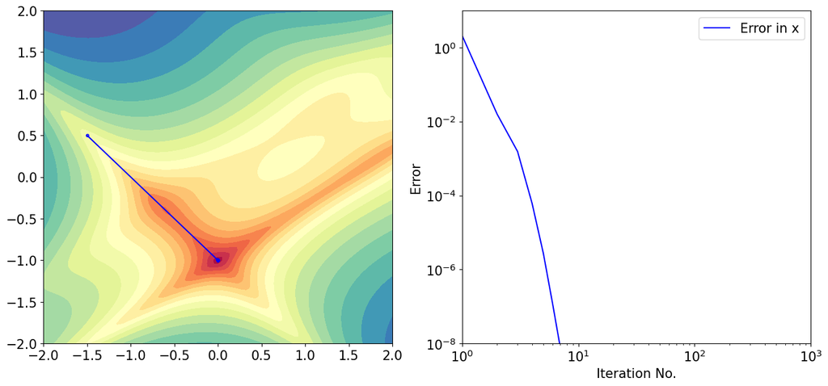

```python
x0 = [-1.5,0.5]
# x0 = [1.0, 0.0]
# xs, fs, gs, hs = gradDesc(FGH, x0, BBLR)
# xs, fs, gs, hs = gradDesc(FGH, x0, BFGS, ifLS=True)
xs, fs, gs, hs = gradDesc(FGH, x0, NR, ifLS=True)

f1, ax = pltFunc()
ax[0] = pltTraj(ax[0], xs)
ax[1] = pltHist(ax[1], xs)
```

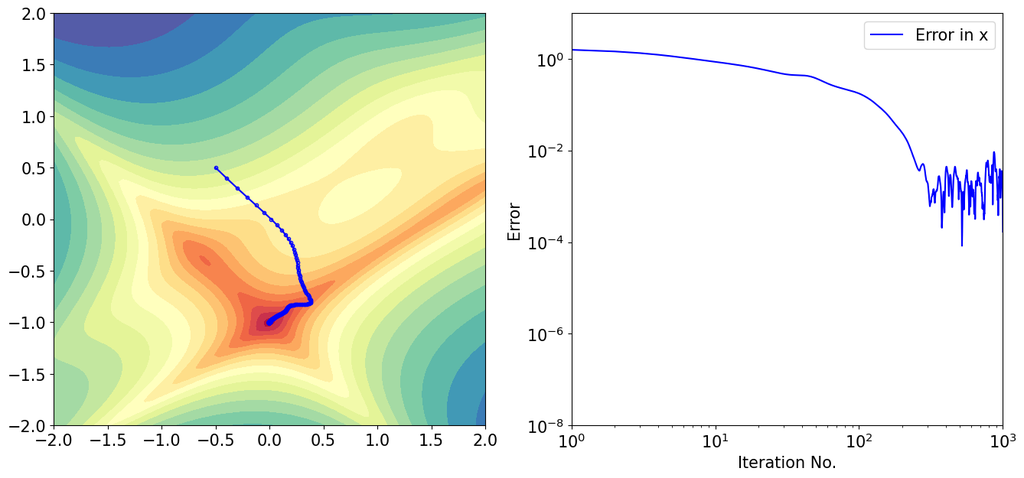

```python
x0 = [-0.5,0.5]
ss = 5.  # Noise in gradient
# xs, fs, gs, hs = gradDesc(FGHS(ss), x0, fixLR(0.0001))
# xs, fs, gs, hs = gradDesc(FGHS(ss), x0, GDM(0.0001,0.9))
# xs, fs, gs, hs = gradDesc(FGHS(ss), x0, AdaGrad(2.0))
# xs, fs, gs, hs = gradDesc(FGHS(ss), x0, RMSProp(0.1,0.9))
xs, fs, gs, hs = gradDesc(FGHS(ss), x0, Adam(0.1,0.9,0.999))

f1, ax = pltFunc()
ax[0] = pltTraj(ax[0], xs)
ax[1] = pltHist(ax[1], xs)
```

### Unfortunately, saddle points prevail in high dimensions

The $\epsilon-\alpha$ curve [1]

- $\alpha$: Percentage of negative eigenvalues of Hessian at critical point (i.e. gradient=0)
- $\epsilon$: Error at critical point
- There are many saddle points (the figure is for a relatively small NN)
- Strong positive correlation between $\alpha$ and $\epsilon$, esp. in high-dim optimization

[figure not shown]

[1] Y. Dauphin et al. Identifying and attacking the saddle point problem in high-dimensional non-convex optimization. NeurIPS 2014.

> Intuitively, in high dimensions, the chance that all the directions around a critical point lead upward (positive curvature) is exponentially small w.r.t. the number of dimensions

Implications:

- If you get a "converged" model and it does not perform well, then the model is likely at a saddle point
- The local minima are likely to be as good as global minima
  - For even larger problems, even saddle points with low index are sufficient (which is more common)
- Now that Hessian-based method might be problematic, we should just use **Gradient Descent**

### Now that we know there are many saddle points and local minima...

- What kind of local minima is better? The **flat** ones - (empirically) better generalization performance
- Compare Adam and vanilla SGD [1]
  - Adam escapes saddle point easier (see the GIF earlier)
  - SGD favors flat minima more

> Additional conclusion from [1]: A small learning rate or large-batch makes it much harder to escape from sharp minima

[1] Z. Xie. A Diffusion Theory For Deep Learning Dynamics: Stochastic Gradient Descent Exponentially Favors Flat Minima. Arxiv: 2002.03495

## Practical aspects in training

- General procedure
- Techniques for improved convergence and better solutions

### Basics: General procedure

- If there are not much data - try cross-validation to use all data
  - i.e., do splits of train-test, so that all data points are used as test once.
- Otherwise, do a split of train-valid-test.
  - Train: for decreasing the loss
  - Valid: for picking the best parameter during training (behave like test in CV)
  - Test: *Completely* unseen in the training process, used to verify the model performance

### Basics: Diagnose your loss curve

- Linearly decrease: increase the learning rate
- Shaky curves: increase the batch size
- Distant train/valid curves: overfitting
- Overlapping train/valid curves: underfitting

[figure not shown]

### Basics: More on loss curves

dev=valid

[figure not shown]

[1] A. Ng, Nuts and Bolts of Building Applications using Deep Learning, NeurIPS 2016

### Intermediate: Caveats and Tuning tricks - I

- Always **normalize** and **shuffle** your data!
  - But normalization factors should be based on **training** dataset only.
- Pick the right learning rate: e.g., Grid search [1], or (cyclic) scheduling [2,3]
  - Higher learning rate for larger batch size (and larger batch-size if you have a bigger machine)

[1] S. Gugger, How Do You Find A Good Learning Rate

[2] I. Loshchilov, SGDR: Stochastic gradient descent with warm restarts, Arxiv: 1608.03983

[3] L. Smith, Cyclical Learning Rates for Training Neural Networks, 2017

### Intermediate: Caveats and Tuning tricks - II

- Pick the right optimizer: Typically start with Adam, fine-tune with SGD
- Start with ReLU or tanh for activation; avoid sigmoid unless for "gate"-like layers
- Try overfitting on a small dataset
  - If your code/model is correct, the training should converge really fast
- Record your training experiments - learn from history

### More techniques

[figure not shown]

[1] R. Sun. Optimization for deep learning: theory and algorithms. Arxiv 1912.08957 *A nice comprehensive summary*